# 2022 metų MMA - 762€!

Justas Mundeikis

2021-09-13

“2022 metų MMA - 762€” - tokia antraštė turėjo puikuotis praėjusią savaitę visuose Lietuvos žiniasklaidos priemonių pirmuose puslapiuose, profesinių sąjungų tinklapiuose, Finansų ministerijai paskelbus [atnaujintą Lietuvos ekonominės raidos scenarijų](https://finmin.lrv.lt/lt/aktualus-valstybes-finansu-duomenys/ekonomines-raidos-scenarijus). Deja, bet verslo atstovai Trišalėje taryboje laimi. Laimi, nes Vyriausybės atstovai pataikaudami verslo lobistams padovanoja milijonus, kurie nebus perskirstyti ir kurie nusės ne Lietuvos darbuotojų kišenėse, įgalinant jų vartojimą, palengvinant didėjančios infliacijos naštą, ar kovojant su skurdo ir socialinės atskirties rizika. Ne, šie milijonai nusės verslo savininkų kišenėse ir ne retai - mokestinių lengvatų šalyse. Dar būtų galima pateisinti, jeigu metus ar dvejus trunkantis toks pataikavimas bent skatintų gamybines investicijas ir taip kurtų pamatus tvariai Lietuvos ekonomikos raidai. Bet ir tuo Lietuvoje nekvepia.

# Šiek tiek priešistorės

Kai Lietuvoje buvo politiškai nuspręsta “depolitizuoti” MMA nustatymo metodiką, pirmus kelerius metus buvo taikyta formulė: *ketvirtadalio didžiausią MMA ir vidutinio darbo užmokesčio santykį turinčių Europos Sąjungos valstybių paskutinių trejų metų vidurkis padauginamas iš Lietuvos Finansų ministerijos skelbiamo einamųjų metų VDU prognozės*. Tokia formule buvo tikimasi baigti kasmet mėnesius trunkančius kivirčus Trišalėje taryboje - įstatai skaičius (kuriuos gali patvirtinti tiek profsąjungų, tiek verslo lobistų atstovai) ir aiškus sekančių metų MMA.

Tačiau tokia formulė nepatiko Lietuvos banko “akanamistams”, kurie nusprendė, kad velniop tą Trišalės tarybos politinį susitarimą ir dvejus metus taikytą metodiką. LB “akanamistai” žino geriau ir patyliukais bruko, bruko ir įbruko savo norimą formulę, kur vietoj *einamųjų metų VDU prognozės* imama *sekančių metų VDU prognozė be priedų ir priemokų*. Problema tik ta, jog LB siūlomą dydį sugeba apskaičiuoti tik LB, be to šis dydis mažiau tikslus nei Finansų ministerijos skelbiamas rodiklis. Dėl abiejų priežasčių pralaimi darbuotojai uždirbantys mažesnį MMA. Negalvokite, jog Socialinės apsaugos ir darbo ministerija apie tokius LB *fintus* nieko nežino. Priešingai, paskutinius porą metų tuo naudojasi, kad kasmet nustatomas MMA būtų mažesnis, nei turėtų būti.

Kai pirmą kartą buvo įbrukta tokia LB metodika, verslas džiaugėsi, profsąjungos - miegojo. Tiesa, džiaugėsi ir Vyriausybė, visgi nemaža dalis MMA gaunančių dirba ir viešajame sektoriuje. O po pirmo karto atsibudusios profsąjungos pasirodė esančios tokios minkštos “depolitizuotose derybose”, kad net santykyje *aukšto ir gražaus* stuburas pasirodo besąs plieninis.

# 2022 metų MMA - 762€

Aš kaip ekonomistas manau, jog būtina laikytis politinio susitarimo ir tos metodikos, kuri buvo taikyta pirmus kelerius metus po “depolitizavimo”, juo labiau, jog pats tuo metu dalyvavau Trišalės tarybos posėdžiuose ir padėjau rasti kompromisą dėl MMA metodikos interpretavimo tarpininkaudamas tarp profsąjungų ir tuometinio premjero Skvernelio patarėjo, dabartinio Seimo nario - Luko Savicko.

| geo | 2018 | 2019 | 2020 | vidurkis_18_20 |
| --- | --- | --- | --- | --- |
| Slovenia | 50.1 | 50.5 | 50.6 | 50.4 |
| Portugal | 49.4 | 50.0 | 51.1 | 50.2 |
| Greece | 46.2 | 50.4 |  | 48.3 |
| France | 48.0 | 48.2 |  | 48.1 |
| Poland | 46.3 | 46.2 | 50.3 | 47.6 |
| Luxembourg | 46.7 | 47.0 | 47.1 | 46.9 |
| Croatia | 44.9 | 46.9 | 46.8 | 46.2 |
| Ireland | 44.6 | 44.5 | 44.7 | 44.6 |
| Spain | 37.9 | 45.6 | 49.6 | 44.4 |
| Romania | 44.4 | 43.9 |  | 44.1 |
| Hungary | 44.8 | 43.7 | 43.2 | 43.9 |
| Bulgaria | 43.6 | 43.2 | 43.6 | 43.5 |
| Netherlands | 43.3 | 43.3 |  | 43.3 |
| Malta | 42.6 | 44.0 | 41.7 | 42.8 |
| Latvia | 45.4 | 42.3 | 40.0 | 42.6 |
| Slovakia | 40.7 | 41.2 | 43.4 | 41.8 |
| Estonia | 41.7 | 38.2 | 44.1 | 41.3 |
| Czechia | 37.9 | 38.4 | 40.8 | 39.0 |
| Germany | 0.4 | 0.4 | 0.4 | 0.4 |

Šių šalių MMA ir VDU santykio vidurkis siekia 48.92 %.

Rugsėjo 10d. [Finansų ministerija atnaujino einamųjų metų VDU prognozę](https://finmin.lrv.lt/lt/aktualus-valstybes-finansu-duomenys/ekonomines-raidos-scenarijus) ir padidino ją iki 1557.8 euro (birželį VDU prognozė siekė 1541.7, kovą tik 1495.1 euro). Tiesiog metų eigoje Finansų ministerijos ekonomistai surenka daugiau patikimų duomenų apie ekonomikos “sveikatą” ir atitinkamai gerina ekonominės raidos prognozes.

Sandauga tarp koeficiento ir VDU prognozės siekia: 0.4892 x 1557.8 = 762.07 arba suapvalinus 762 eurus.

# Kodėl MMA yra gera priemonė perskirstymui?

Minimalus mėnesinis atlyginimas yra ne kas kita, kaip darbo vaisių (įmonės uždirbtų pajamų) perskirstymo mechanizmas, kuris turi užtikrinti, jog mažiausias pajamas gaunantys darbuotojai nebūtų išnaudojami (nes ir jų derybinė galia yra silpniausia) ir gautų adekvačią uždirbamų pajamų dalį. Indeksavimas su VDU iš tiesų yra labai paprastas ir kartu efektyvus, nes MMA uždirbantys visada lygina save su kitais dirbančiaisiais, todėl pati formulė yra beveik ideali (tik kad jos kas laikytųsi…). Augant vidutiniam darbo užmokesčiui, kuris kartu atspindi ir kainų augimą ir produktyvumo augimą(!), atitinkamai proporcionaliai yra didinamas ir MMA. Kartu verslas susidurdamas su vis labiau brangstančia darbo jėga turi priimti atitinkamus sprendimus - arba investuoti į tai, jog didėtų darbo jėgos sukuriamos produkcijos vertė ir verslas galėtų mokėti didesnius atlyginimus, arba jeigu tam nėra sąlygų - atleisti darbuotojus ir nelaikyti jų užimtų neproduktyvioje veikloje.

Taip, tas “atlaisvinti nuo neproduktyvios veiklos” skamba ciniškai, nes individualiai tai reiškia nedarbą. Tačiau šioje vietoje ir reikalinga stipri ir efektyvi valstybė - socialinės garantijos darbo netekusiems, kurios užtikrina jog žmonės turėtų už ką pirkti maisto, susimokėti už būstą ir kartu prasmingos perkvalifikavimo galimybės, galbūt net su persikraustymo į didesnius miestus išmokomis, skatinančiomis darbo netekusius ieškoti ne tik naujo, bet ir aukštesnę pridėtinė vertę kuriančio darbo. Šias galimybes gali užtikrinti tik mokami mokesčiai, tiek verslo, tiek dirbančiųjų, tiek vartotojų.

Tačiau turime ką turime, aibę metų Lietuvos verslas daro viską: verkia kaip negali mokėti atlyginimų, verkia, kaip vis bankrutuoja ir nori mažesnių mokesčių, verkia, kaip reikia leisti didinti kvotas darbuotojams iš trečiųjų šalių, kurie dempinguotų vietinės darbo jėgos kainą, bet va ko nedaro, tai neinvestuoja į gamybinius pajėgumus, kurie užtikrintų, jog Lietuvoje gamyboje būtų kuriama aukštos pridėtinės vertės produkcija.

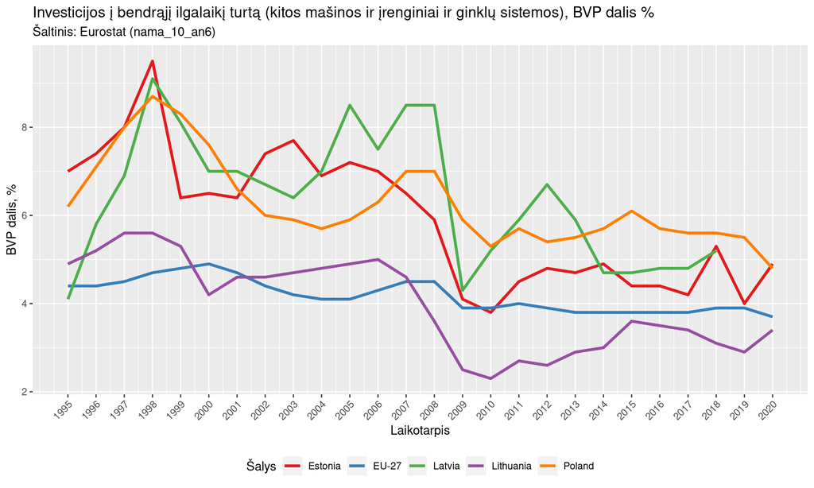

Vyriausybė irgi, vietoj to, kad iškeltų konkrečius tikslus užimtumo tarnybai, skirtų reikiamą ir adekvatų finansavimą tam, jog nedirbantieji būtų deramai perkvalifikuoti ir mažėtų nedarbas Lietuvoje - to daryti negali, nes “pinigų tam nėra”. Mokesčių ir BVP santykis Lietuvoje vienas žemiausių ES, atitinkamai, ir valstybės pajėgumai.

Tad ir lieka Vyriausybei patogu, pataikauti verslui, nedidinti MMA tiek, kiek sutarta. O koks skirtumas? Juk invalidės profsąjungos: LPSK, Solidarumas ir Sandrauga, vis tiek nesurinks niekad tokios protestuojančios minios, kiek surenka koks Šeimų Sąjūdis, apie streikus Lietuvoje net svajoti nereikia - tapome nepriklausomi, bet ne nuo vergų mentaliteto.

# Kam atiteks tie milijonai?

32 eurai kurių negaus dirbantys už MMA (762-730=32) padauginus iš 12 darbo mėnesių atitinka 384 eurus. Taip dalis šios sumos būtų sumokama mokesčiams ar socialinio draudimo įmokoms, tačiau atskaičius liktų apie 220 eurų kišenėje per metus daugiau. Galima diskutuoti, ar per metus gauti 220 eurų pvz., vienišai mamai ar vienišam tėčiui auginantiems vaiką yra daug ar mažai, bet turint omenyje skurdo rizikos ir socialinės atskirties rodiklius, manau jog tokios šeimos šiomis įplaukomis apsidžiaugtų. Ir ne tik apsidžiaugtų, bet ir išleistų, ne jachtoms, ar *bentlėjams*, bet vartojimui. Žemiau pateiktame grafike galima aiškiai matyti, jog net kas penktas namų ūkis, kuriame gyvena vienas suaugęs su vienu ar daugiau vaikų, patiria didelį materialinį nepriteklių (sakykime tiesiai šviesiai - gyvena absoliučiame skurde).

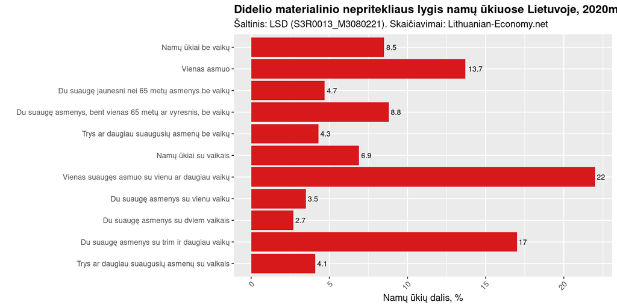

Darbuotojams atitenkanti didesnė pajamų dalis iškart grįžtų per vartojimo mokesčius į biudžetą, dalis grįžtų Lietuvoje veikiančioms įmonėms per didėjančią paklausą. Todėl senai laikas verslo lobistams, sėdintiems eteriuose, nustoti mulkinti tautą, esą MMA didinimas yra kone mokesčių didinimas. Ne, tai vartojimo ir kartu investicijų skatinimas!

Tiesa, atsakyti kiek Lietuvoje yra MMA uždirbančių asmenų, negali niekas. Tokios statistikos 21 amžiaus ir “big data” (lt. - didžiųjų duomenų) laikmetyje Lietuvoje dar niekas nesugalvojo surinkti. Galime tik spėti, jog turime apie 80-120 tūkstančių darbuotojų, kurių atlyginimas tiesiogiai priklauso nuo MMA (taip, keliasdešimt tūkstančių Lietuvoje dirbančių tolimųjų reisų sunkvežimių vairuotojų iš trečiųjų šalių atlyginimas irgi tiesiogiai priklauso nuo MMA).

Paimkime 100 000 darbuotų netenkančių 384 eurų darbo užmokesčio per metus ir pamatysime, jog Vyriausybės pataikavimas verslui kartu su profesinių sąjungų invalidumu atima iš dirbančiųjų 38.4 milijonus eurų.